# Selecting differentially expressed genes with R or TmeV

Denis Puthier and Jacques van Helden

2015-03-09

## Retrieving the den Boer normalized dataset

Here we will use data from the microarray series GSE13425, which which was retrieved from the [Gene Expression Omnibus](http://www.ncbi.nlm.nih.gov/geo/) ([GEO](http://www.ncbi.nlm.nih.gov/geo/)) database. In this experiment, the authors applied a supervised classification method to define a transcriptomic signature, in order to classify samples from acute lymphoblastic leukemia (ALL). Lymphoblastic leukemia is characterized by the abnormal clonal proliferation, within the bone marrow, of lymphoid progenitors blocked at a precise stage of their differentiation.

Data were produced using Affymetrix geneChips (Affymetrix Human Genome U133A Array, HGU133A). Information related to this platform are available on GEO website under identifier GPL96.

## Loading data into R

### Protocol

- Start R.
- Have a look at the description of the **read.table()** function.
- We will now load three data tables into R using the read.table function. The function allows us to directly read the tables from the web server. We will successively load 3 files providing complementary information.
  - the expression matrix (GSE13425_Norm_Whole.txt)
    - Contains genes as rows and samples as columns.
    - Data were previously normalized using rma algorithm (they are thus transformed in logarithm base 2).
  - the A/P/M matrix (GSE13425_AMP_Whole.txt)
    - Indicates whether a gene was called **A**bsent, **P**resent or **M**arginal.
  - Phenotypic data (GSE13425_phenoData.txt)
    - The GSE13425_phenoData.txt file contains phenotypic information about samples.

```r
## Get some help about the read.table fonction
#?read.table

## Define the URL of the example data sets
url.course <- "http://pedagogix-tagc.univ-mrs.fr/courses/ASG1"
url.base <- file.path(url.course, "data/marrays/")

## Load expression values
expr.file <- file.path(url.base, "GSE13425_Norm_Whole.txt")
expr.matrix <-  read.table(expr.file,sep="\t", head=T, row=1)

## Load phenotypic data
pheno <- read.table(file.path(url.base, 'phenoData_GSE13425.tab'),
                    sep='\t', head=TRUE, row=1)

## Load Absent/Marginal/Present (AMP) calls
amp <- read.table(file.path(url.base, "GSE13425_AMP_Whole.txt"),
                  sep="\t", head=T, row=1)
```

We will now define a directory to store the results on our computer.

```r
## Define the output directory. You can adapt this to your local configuration.
dir.output <- "~/ASG1_practicals/GSE13425"

## Create the output directory (if it does not exist yet)
dir.create(dir.output, showWarnings=FALSE, recurs=TRUE)

## Change directory to dir.output
setwd(dir.output)
```

### Exercise

- How many rows and columns does the object expr.matrix contain
- Does it correspond to the dimensions of the A/P/M matrix ?
- Which information is available about samples ?
- How many samples from each tumor subtype are present in the DenBoer dataset ?

View solution| Hide solution

## Basics about Welch’s t test

Welch’s test is a variant of the classical Student test, whose goal is to test the equality between two means.

$H_0: m_{g,1} = m_{g,2}$

where $m_{g,1}$ and $m_{g,2}$ represent the **respective mean expression values for a given gene $g$ in two populations** (for example, all existing patients suffering from T-ALL versus all patients suffering from pre-B ALL). Of course, we do not dispose of measurements for all the patients suffering from these two types of ALL in the world (the population). We only dispose of two sets of samples, covering 36 (T-ALL) and 44 (pre-B ALL) patients, respectively. On the basis of these samples, we will estimate how likely it is that genes $g$ is generally expressed at similar levels in the populations from which the samples were drawn.

The essential difference between **Student** and **Welch** is that the proper Student test relies on the assumption that the two sampled populations have the **same variance**, whereas Welch’s test is designed to treat populations with **unequal variances**.

When detecting differentially expressed genes, **we cannot assume equal variance**. Indeed, a typical case would be that a gene of interest is expressed at very low level in the first group, and high level in the second group. The inter-individual fluctuations in expression values are expected to be larger when the gene is expressed at a high level than when it is poorly expressed. It is thus generally recommended to use Welch rather than Student test when analyzing microarray expression profiles.

**BEWARE**: Student and Welch tests **assume data normality**. Affymetrix microarray intensities are far from the normal distribution, even after log transformation. However, **t-test is robust to non-normality if there is a sufficient number of samples per group**. In the subsequent exercise, we will apply Welch test to detect genes differentially expressed between cancer types represented by ~40 samples each. We are thus in **reasonably good conditions** to run a Welch test. Nevertehless, in a next section we will also apply a non-parametric test (Wilcoxon), which does not rely on an assumption of normality.

Welch’s t-test defines the t statistic by the following formula:

$t=\frac{\bar{x_1} - \bar{x_2}}{\sqrt{\frac {s^2_1}{n_1} + \frac{s^2_2}{n_2}}}$

Where:

- $\bar{x_i}$ is the sample mean,
- $s^2_{i}$ the sample variance,
- $n_{i}$ the sample size.

The **t.test()** function can be used to calculate this score (and additional informations such as p.value). This function returns an **S3 object** whose slots can be listed using the **names()** function and accessed using the **$ operator** (such as with lists in R).

### A first intuition

In order to get an intuition of the $t$ statistics, let us create artificial datasets and compute the associated $t$ value. In the following example $x$ and $y$ can be viewed as the expression values for gene $g$ in two different classes of cancer.

Assuming that each group contains 4 patients, we will generate 4 random numbers following a normal distribution, to simulate the groups 1 and 2. We deliberately set the means to the same values (to fall under the null hypothesis), but we generate them with different standard deviations.

```r
x <- rnorm(n=4, mean=6, s=1)
y <- rnorm(n=4, mean=6, s=2)
```

- Compute the associated $t$ value using the **mean**, **sd** and **sqrt** functions.

View solution| Hide solution

- Now we can check that the same result is obtained using the **t.test** function implemented in R.

View solution| Hide solution

## Applying Welch’s t-test to the den Boer dataset

We would like to define genes that discriminate between “hyperdiploid” tumors and tumors of all the other subtypes represented by at least 10 samples in Den Boer dataset.

One possibility would be to iterate over all probesets, and to successively run the R method **t.test()** on each one. This would however be quite inefficient, and the results would not be very easy to handle, since it would be a list of objects of the class t.test.

Instead, we will use a custom function that runs Student or Welch test in parallel on all the elements of a data table.

### Running t-tests on each row of a data matrix

#### Installing the qvalue library

First we need to check if the *qvalue* library is installed (we will give more information about q-values in the next sessions).

```r
### Running t-tests on each row of a data matrix
## We must first check if the q-value library from Bioconductor has
## been installed (if not, will be installed here)
if (!require("qvalue")) {
  source("http://bioconductor.org/biocLite.R")
  biocLite("qvalue")
}
```

#### Loading the function *t.test.multi()*

The we will load a custom script written by J. van Helden (**Note:** the utilities for this course will soon be converted to an R package, in order to facilitate their installation and use).

```r
## Load a custom the library for multiple t tests
url.stats4bioinfo <- "http://pedagogix-tagc.univ-mrs.fr/courses/statistics_bioinformatics"
source(file.path(url.stats4bioinfo, 'R-files/config.R'))
```

```
## [1] "Data repository http://pedagogix-tagc.univ-mrs.fr/courses/statistics_bioinformatics/data"
## [1] "R scripts source http://pedagogix-tagc.univ-mrs.fr/courses/statistics_bioinformatics/R-files"
## [1] "Results will be saved to /Users/jvanheld/course_stats_bioinfo/results"
## [1] "Figures will be saved to /Users/jvanheld/course_stats_bioinfo/figures"
```

```r
source(file.path(url.stats4bioinfo, 'R-files/util/util_student_test_multi.R'))
```

For the sake of curiosity, you can also have a look at the [R code](http://pedaogix-tagc.univ-mrs.fr/courses/statistics_bioinformatics/R-files/util/util_student_test_multi.R).

#### Defining sample groups

We will select genes differentially expressed between one subtype of interest (for example *hyperdiploid*) and all the other types of ALL represented by at least 10 samples. For the rest of the tutorial, we will refer to these subtypes as *“Other”*.

```r
## Classes to keep
print("Selecting cancer subtypes with >= 10 samples")
```

```
## [1] "Selecting cancer subtypes with >= 10 samples"
```

```r
class.freq <- table(pheno$Sample.title)
classes.to.keep <- names(class.freq[class.freq>10])
subtype.of.interest <- "hyperdiploid"
classes.other <- setdiff(classes.to.keep, subtype.of.interest)
print(classes.to.keep)
```

```
## [1] "hyperdiploid" "pre-B ALL"    "T-ALL"        "TEL-AML1"
```

```r
## Define a Boolean vector indicating which samples belong
## to the two selected subtypes.
samples.to.keep <- pheno$Sample.title %in% classes.to.keep
sum(samples.to.keep)
```

```
## [1] 167
```

```r
## Extact a subset of expression matrix with only the two selected sets
expr.matrix.kept <- expr.matrix[,samples.to.keep]

## Export the table with the selected samples, in order to open it with TMEV
setwd(dir.output)
file <- paste(sep="", "GSE13425_Norm_",subtype.of.interest,"_vs_Other_ge10samples.txt")
write.table(expr.matrix.kept,
            file,
            col.names=NA,quote=F,sep="\t")


## Define a vector with the sample types for the two selected cancer subtype
sample.group <- as.vector(pheno[samples.to.keep, "Sample.title"])
names(sample.group) <- names(expr.matrix[samples.to.keep])
sample.group[sample.group != subtype.of.interest] = "Other"

## Count the number of samples per group (ALL subtype)
table(sample.group)
```

```
## sample.group
## hyperdiploid        Other
##           44          123
```

```r
## Export sample groups, which will be used in other practicals
## (e.g. supervised classification)
setwd(dir.output)
file <- paste(sep="",
              "GSE13425_Norm_",subtype.of.interest,"_vs_Other_sample_groups.txt")
write.table(as.data.frame(sample.group),
            file,
            col.names=FALSE,
            row.names=TRUE,
            quote=F,sep="\t")
```

#### Compute Welch t-test for each gene

We will now apply the **Welch test** on **each gene** of the Den Boer dataset, in order to select genes differentially expressed between the subtype of interest (*“hyperdiploid”*) and the other subtypes represented by at least 10 genes.

```r
## Run the Welch test on each probesets of the DenBoer expression matrix.
## We will store the result in a table called "DEG" for "Differentially expressed genes", which will later be completed by other tests (e.g. Wilcoxon).
denboer.deg <- t.test.multi(expr.matrix.kept, sample.group, volcano.plot=FALSE)
```

```
## [1] "Mon Mar  9 14:39:43 2015 - Multiple t-test started"
## [1] "Mon Mar  9 14:39:45 2015 - Multiple t-test done"
```

```r
## Inspect the result table
dim(denboer.deg)
```

```
## [1] 22283    17
```

```r
names(denboer.deg)
```

```
##  [1] "mean.Other"           "mean.hyperdiploid"    "means.diff"
##  [4] "var.est.Other"        "var.est.hyperdiploid" "sd.est.Other"
##  [7] "sd.est.hyperdiploid"  "st.err.diff"          "t.obs"
## [10] "df.welch"             "P.value"              "E.value"
## [13] "sig"                  "fwer"                 "q.value"
## [16] "fdr"                  "rank"
```

```r
## Select genes with a stringent threshold on E-value
eval.threshold <- 0.05
significant.probesets <- denboer.deg$E.value <= eval.threshold
table(significant.probesets) ## Count the number of significant probesets
```

```
## significant.probesets
## FALSE  TRUE
## 20921  1362
```

#### Comparing sample means

We will compare the mean expression value between hyperdiploids and the other selected subtypes, and highlight the significant genes.

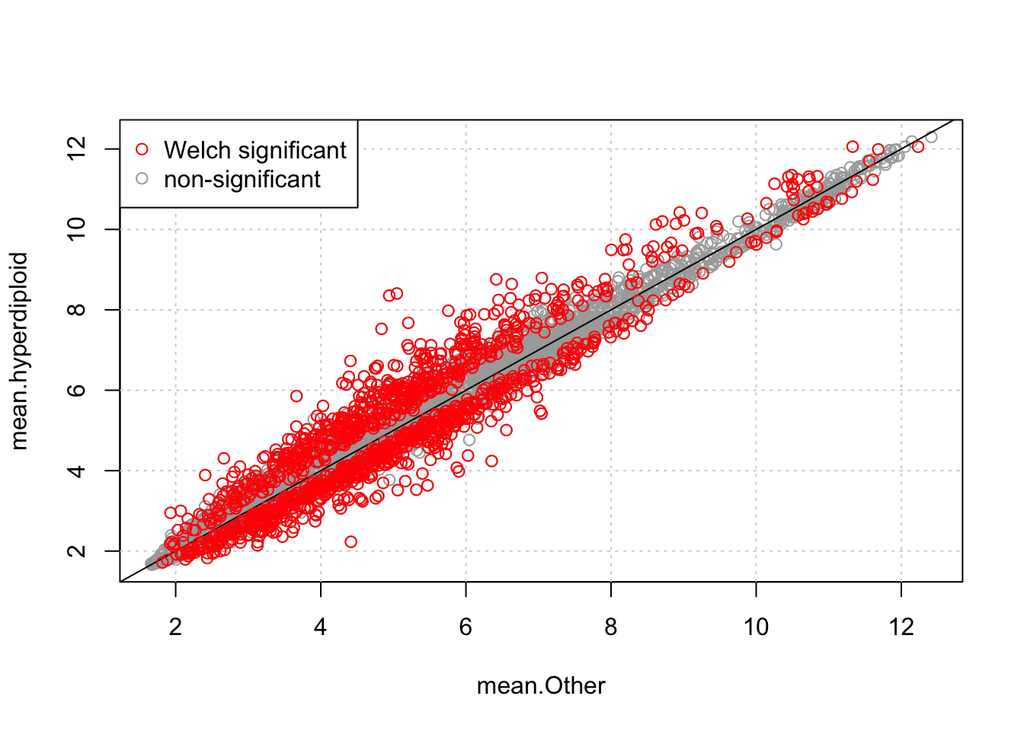

```r
## Plot the gene-wise means
plot(denboer.deg[, c("mean.Other", "mean.hyperdiploid")], col="darkgray")
grid()

abline(a=0,b=1, col="black") # Draw the diagonal line

## Highlight significant genes
lines(denboer.deg[significant.probesets,
                  c("mean.Other", "mean.hyperdiploid")],
      type='p', col="red")
legend("topleft",col=c("red", "darkgray"),
       legend=c("Welch significant","non-significant"),
       pch=1)
```

#### Exercise

- How do you explain that the regions covered by gray (non-significant) and red (significant) probesets overlap on the mean-mean plot ?

View solution| Hide solution

## Comparing the p-values of Welch and Wilcoxon tests

### The apply function

The **apply** function can be used to apply a given function to a matrix or data.frame. This function has tree required arguments:

```r
args(apply)
```

```
## function (X, MARGIN, FUN, ...)
## NULL
```

- X the matrix/data.frame
- MARGIN: 1 or 2 depending on wether the function has to be applied on rows or columns, respectively.

### Defining a new function: **return.t()**

In the line below, we define a function called **return.t()**, to run the Welch test on a single probeset of the microarray table.

```r
## Define a function to return the p-value of a Welch test
return.t <- function(x,y){  t.test(x[y==subtype.of.interest], x[y=="Other"], alternative="two.sided", var.equal=FALSE, paired=FALSE)$p.value}
```

- Use this function to compute the p-value of the Welch’s t test for all probesets of expr.matrix.
- Define a similar function to compute the p-value of Wilcoxon’s test to each probeset.
- Draw a plot to compare the p-values returned by the respective tests.

View solution| Hide solution

## Drawing a volcano plot

The volcano plot is a classical representation of differential expression analysis. In this diagram, the **x axis represents the log** ratio and the **y axis the result of a statistic** expressed as $-log10(p-value)$.

### Computing the log ratio

#### Exercise

- Calculate for each gene its average expression level in the “hyperdiploid” and “other” classes.
- Calculate the difference of the mean for each gene (log ratio).

View solution| Hide solution

### Volcano plot

#### Exercise

- Draw a volcano plot.
- Use the identify function to find the names of some interesting genes.

View solution| Hide solution

## Significance Analysis of Microarrays (SAM)

### What is SAM ?

Probably the most popular method for differential expression analysis of microarray data is “Significance Analysis of Microarrays” (SAM). SAM will compute for each gene a score $d$ which is close to the $t$ statistics of the welch’s test. However, it won’t require any assumption about the data distribution. In order to compute the expected distribution of $d$ under the null hypothesis SAM will performe a set of permutations on the class labels, and compute each time a simulated sets of results for the $d$ statistics. The observed and simulated results will be used to compute FDR values. Sam is implemented in several R libraries (e.g: *siggenes*). Here we will use a more interactive program called [“MultiExperiment Viewer (MeV)](http://www.tm4.org/mev.html).

### Installing Mev on Linux system

If you are working on a Linux system, the commands below can be used to download and compule MeV on the Linux console.

```
mkdir -p ~/bin
cd ~/bin
wget "http://freefr.dl.sourceforge.net/project/mev-tm4/mev-tm4/MeV%204.8.1/MeV_4_8_1_r2727_linux.tar.gz"
tar xvfz MeV_4_8_1_r2727_linux.tar.gz
cd -
echo -e "\nalias tmev=\"cd ~/bin/MeV_4_8_1/; sh -c 'nohup ./tmev.sh &'; cd -\"" >> ~/.bashrc
source ~/.bashrc
tmev
```

### Filtering genes on the basis of the absent/marginal/present (A/M/P) filter

The classical processing pipeline defined by Affymetrix associates a qualitative tag to each probeset, with three possible values:

- absent (A)
- marginal (M)
- present (P)

An **absent** call means that no significant signal was detected with the associated probeset. However, this “absence” might either indicate that the gene is not expressed in this particular sample, or that the gene is undetectable (irrespective of its expression level) due to some technical problem with this specific probeset.

It became a classical practice to filter out the genes called “absent” on an important fraction of the samples in a given series, by implicitly assuming that their recurrent absence reveals a technical problem rather than a biologically relevant effect (repression of the gene).

#### Exercise

View solution| Hide solution

#### Solution

```r
## Select a subset of the A/M/P matrix
amp.sub <- amp[,samples.to.keep]
dim(amp)
```

```
## [1] 22283   190
```

```r
dim(amp.sub)
```

```
## [1] 22283   167
```

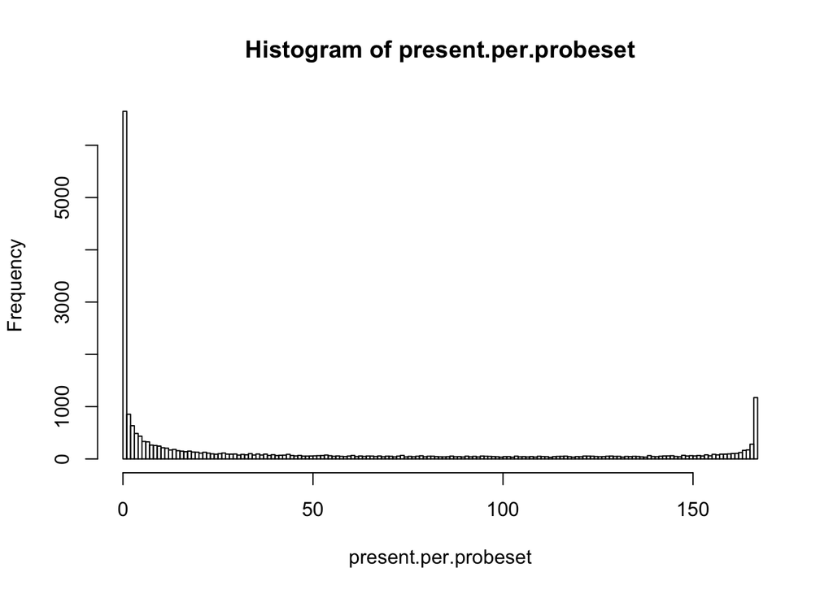

```r
## Count the number of "Present" calls per probeset
isPresent <- amp.sub == "P"
present.per.probeset <- rowSums(isPresent)
hist(present.per.probeset, breaks=0:ncol(amp.sub))
```

```r
## "Present filter":  Select probeset declared present in at least 25% of the samples
retained <- rowSums(isPresent) >=  0.25*ncol(expr.matrix.kept)
table(retained) ## Count number of retained and rejected probesets
```

```
## retained
## FALSE  TRUE
## 14013  8270
```

```r
## Select a subset of the matrix with the retained probesets only
expr.matrix.kept <- expr.matrix.kept[retained, ]

## Check the number of probes (rows) and samples (columns) of the
## selected expression table
print(dim(expr.matrix.kept))
```

```
## [1] 8270  167
```

```r
## Export the table with the selected samples, in order to open it with TMEV
setwd(dir.output)
file <- paste(sep="", "GSE13425_Norm_",subtype.of.interest,"_vs_Other_present30pc.txt")
write.table(expr.matrix.kept,
            file,
            col.names=NA,quote=F,sep="\t")
```